# Causal Diagrams (DAGs)

STAT 341, SP23

2023-01-25

# Beyond One Parameter

So far we started simple, fitting one-parameter models. But we will soon want to expand to more than one, especially because we are interested in *relationships* between variables – for example, not just “what proportion of patents are for products?” but “what’s the effect of changes in import tariffs on the proportion of product patents?”

# What’s a Causal Diagram?

A **causal diagram** is a picture mapping the causal relationships between key variables. They are used when researchers are interested in quantifying *causal* relationships between variables – not just, “is *X* associated with a change in *Y*?” but “does *X* *cause* a change in *Y*?”

To make causal conclusions with confidence outside the context of a randomized, controlled experimental study is a big challenge, and mapping out starting assumptions about relationships between variables is a key first step.

Even if you are not necessarily trying to make strong causal conclusions, when you model relationships of several variables, a causal diagram helps you make *smart, thoughtful* choices about the ones you *include in* your model and the ones you *leave out*. The diagram surfaces your starting assumptions about relationships between variables. It makes your assumptions transparent (to others and to you!) and guides choices about what to include/exclude from a model.

People also call causal diagrams **DAG**s (for **Directed Acyclic Graphs**) since they are a specific application of that [broader] type of mathematical graph. So, every causal diagram is a DAG, but in math there can be DAGs that are not statistical causal diagrams.

In a causal diagram each box is a variable, and arrow connect causes to effects (with the arrowhead pointing from the cause to the effect).

# Drawing Causal Diagrams in R

To draw causal diagrams in R, we will use the package `dagitty` (supplemented by `CalvinBayes`) so make sure you have `library()` calls for those packages before you start.

```r
library(dagitty)
library(CalvinBayes)
```

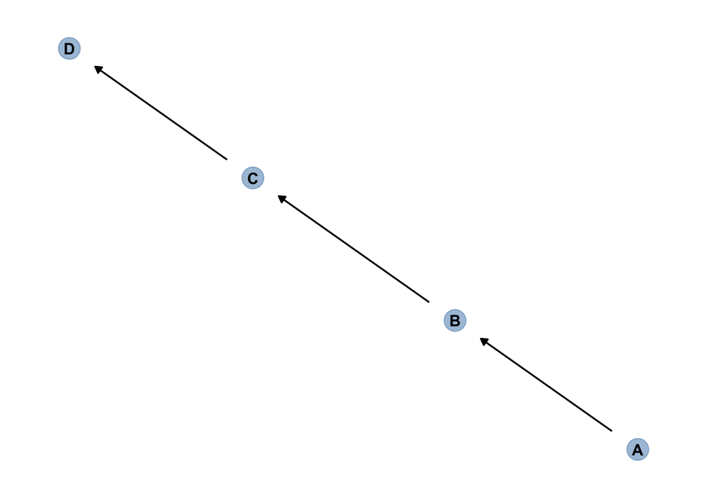

```r
# create the DAG object
causal_diagram_1 <- dagitty("dag{
  A -> B;
  B -> C;
  C -> D
}")
# plot it
gg_dag(causal_diagram_1)
```

Things to try:

- What kind of more-informative names can you use other than just A, B, C, etc? Are words okay? Spaces?
- How do the -> relate to the arrows in the plot?
- What happens if you add or remove a line inside the `dag{}` specification?

# Variable Types

In a multi-variable analysis, there is often one key variable of interest (measuring “response” or “effect”) and another one which may influence it, and is the focus of greatest research interest (“predictor” or “cause”).

But there are generally other variables in the mix that are somehow relevant to understanding the predictor – response relationship. How can we classify (and diagram) them?

In all examples below, **X** is the predictor of interest and **Y** is the response. (**A** is the other variable.)

## Precision Covariate

Here’s an example of **A** acting as a **precision covariate**. Precision covariates are also known as **competing exposures**. Based on the diagram (and the code), explain in words what a **precision covariate** is.

*Notice how the `gg_dag()` inputs `size` and `highlight` affect the diagram!*

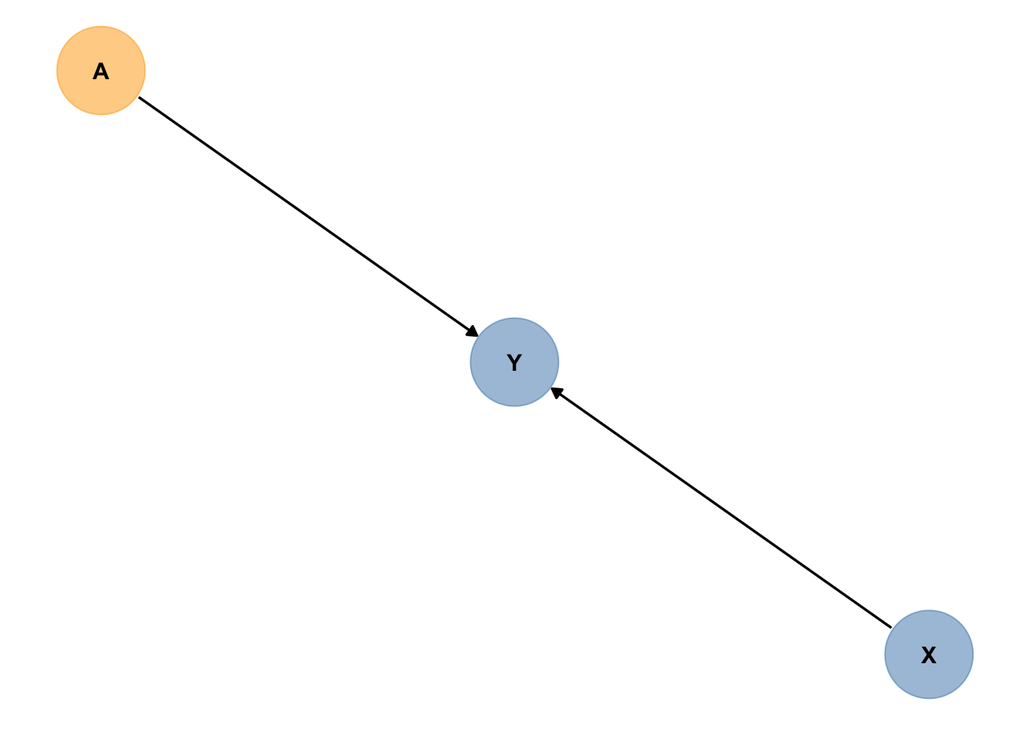

```r
precision_ex <- dagitty("dag{
  X -> Y
  A -> Y
}")
gg_dag(precision_ex,
       size = 20,
       highlight = 'A')
```

Best practice is to *include* precision covariates in a model trying to measure the size of the effect of X on Y, to get the most *precise* estimates possible…but if you don’t, it won’t bias your estimate of the size of X’s influence on Y. Can you explain why?

## Mediator

Here are two (slightly different) examples of **A** acting as a mediator. Based on the diagram (and the code), explain in words what a **mediator** is.

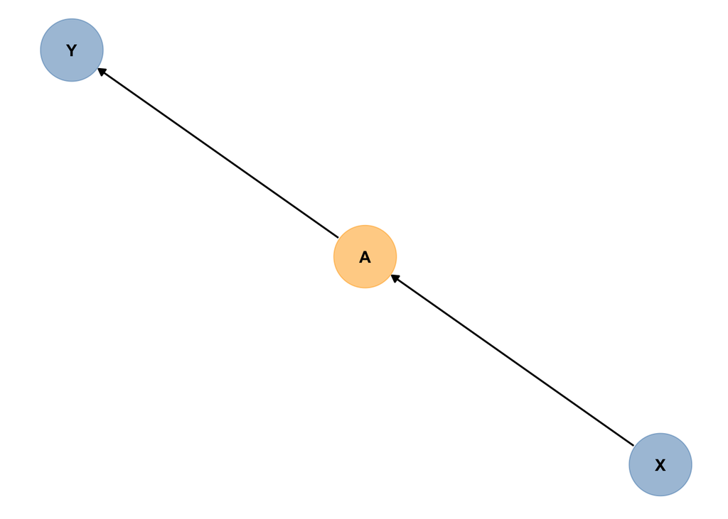

```r
mediation_ex <- dagitty("dag{
  X -> A
  A -> Y
}")
gg_dag(mediation_ex,
       size = 20,
       highlight = 'A')
```

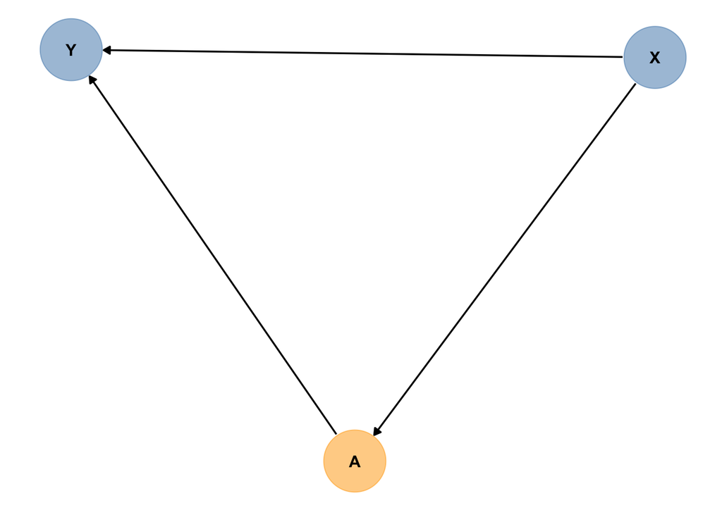

```r
mediation_ex2 <- dagitty("dag{
  X -> A
  A -> Y
  X -> Y
}")
gg_dag(mediation_ex2,
       size = 20,
       highlight = 'A')
```

How is this *different* from a precision covariate?

In modeling, you might choose to estimate the **total relationship** of X and Y by omitting mediator A from your model; or, you might include both, to tease apart influences of X on Y via A, and not via A. Both can be valid. Researchers have to choose which they *want* to do.

## Confounder

Both code examples below produce the same causal diagram, in which A is a **confounder**. Can you define “confounder” in words?

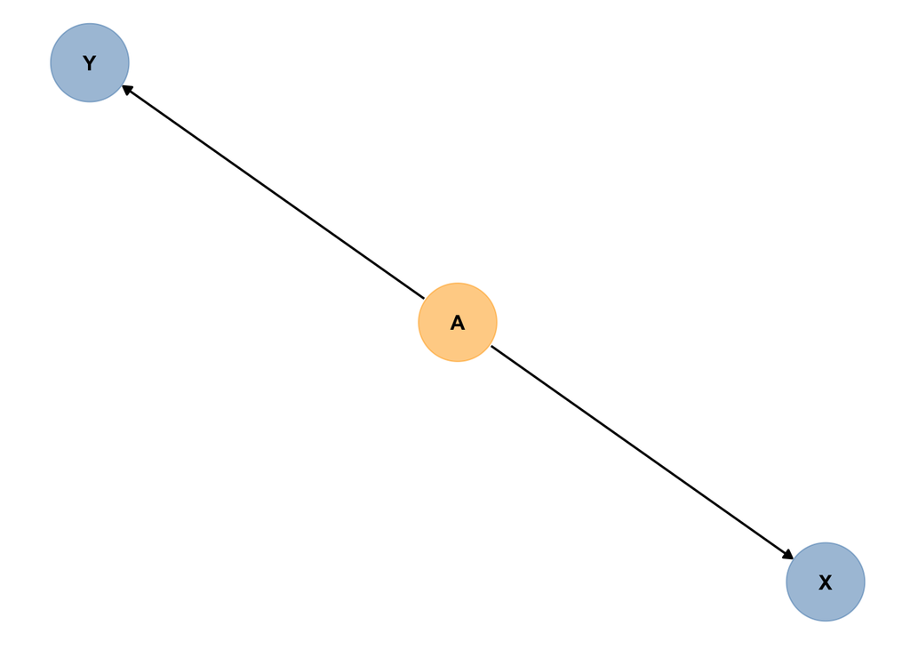

```r
confound_ex <- dagitty("dag{
  A -> X
  A -> Y
}")
gg_dag(confound_ex,
       size = 20,
       highlight = 'A')
```

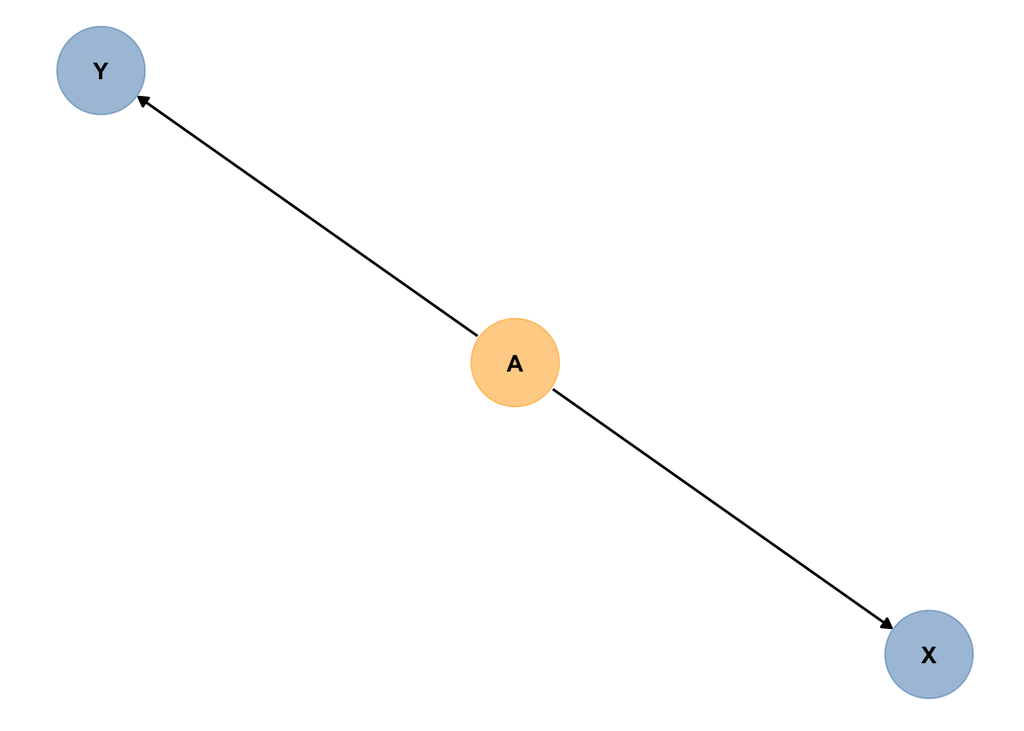

```r
# nifty trick for daggity() when one variable has causal links to more than one other:
# (same picture results)
confound_ex2 <- dagitty("dag{
  A -> {X Y}
}")
gg_dag(confound_ex2,
       size = 20,
       highlight = 'A')
```

If there is a **confounder** present and you *do not* include it in your model, then you may *wrongly conclude X causes Y*. So best practice is to *include* all confounders in a model.

## Collider

**Collider** bias caused by collider variable A looks like:

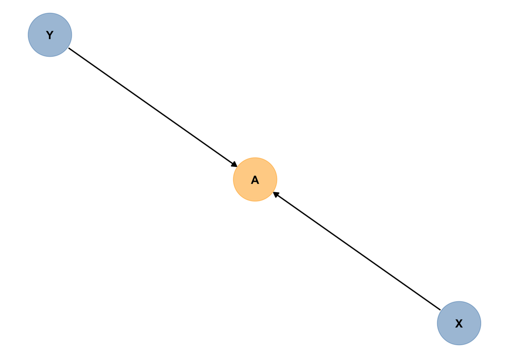

```r
collide_ex <- dagitty("dag{
  X -> A
  Y -> A
}")
gg_dag(collide_ex,
       size = 20,
       highlight = 'A')
```

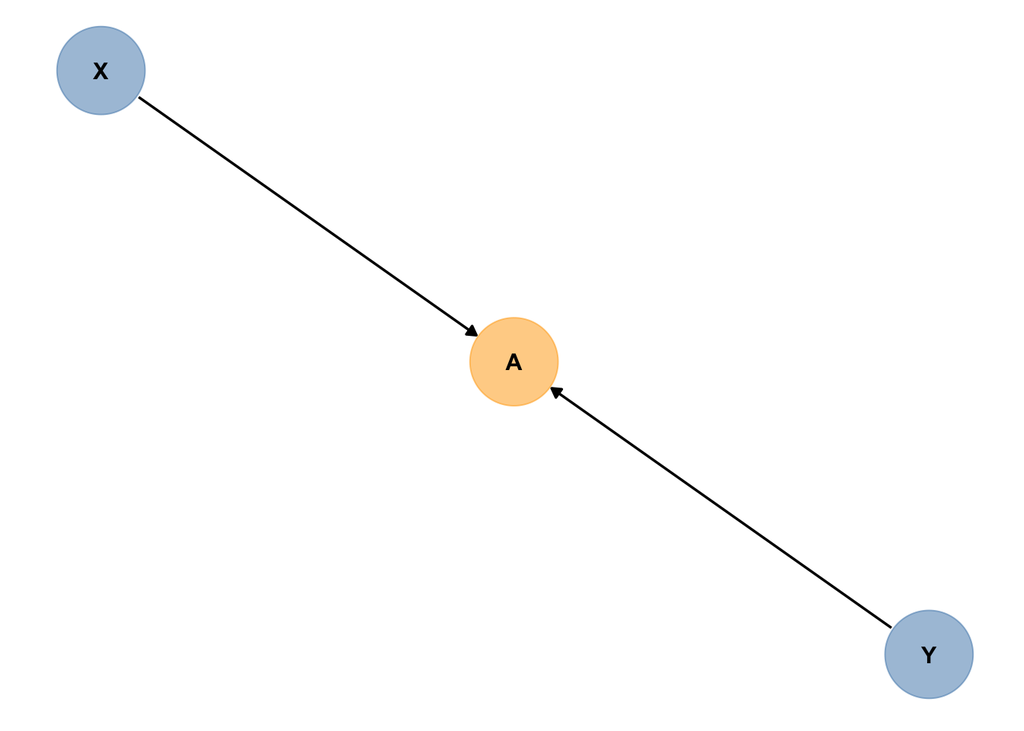

```r
# or another (shorthand) way to write  it:
collide_ex2 <- dagitty("dag{
  {X Y} -> A
}")
gg_dag(collide_ex2,
       size = 20,
       highlight = 'A')
```

Including a **collider** in a model designed to measure association between X and Y *can induce association where there is actually none* so best practice is to make sure you **do not include colliders in models.**

## Moderator

A variable that *moderates* (increases or decreases the size of) the causal link between two other variables is a **Moderator.**

(If you have studied *interactions* before in the context of regression models, a cause and a moderator *interact* to influence the effect.)

Unfortunately *our software currently doesn’t have an adequate way to draw moderators* – for [good reasons](https://academic.oup.com/ije/article/51/4/1047/6607680) – but here’s a diagram (from [Yoon 2020](https://link.springer.com/article/10.1007/s40815-020-00848-3)) to help get a sense of the situation:

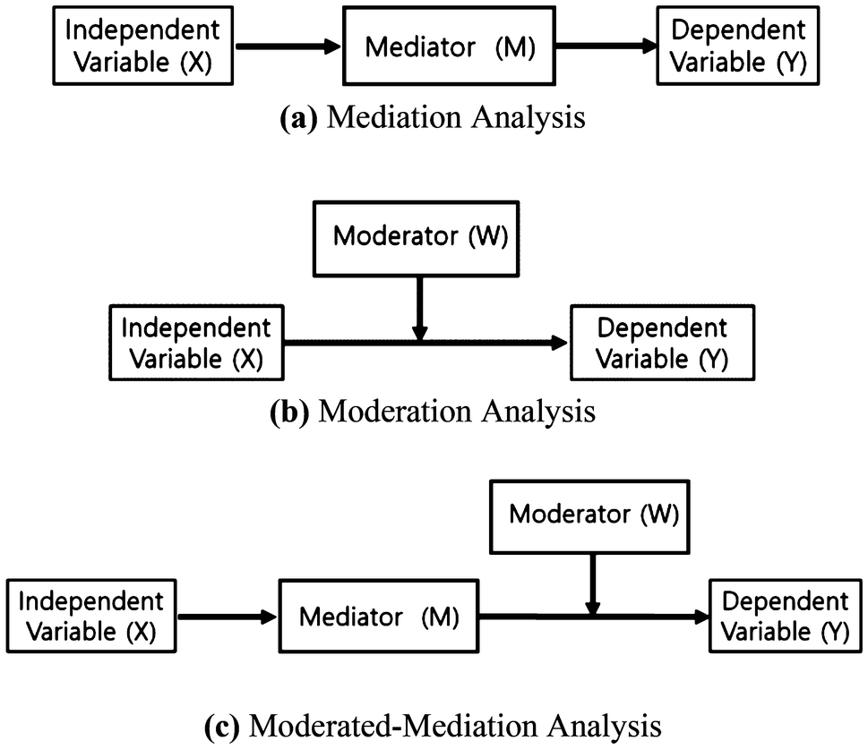

If you think you have a moderator variable, best practice is to *include* it in your model *interacting* with **X**. (This is advanced - we may return to it later in the course.)

## More

There are more details and more complicated scenarios, of course. This is all you need to master to start with. If you want to explore more, check out https://cran.r-project.org/web/packages/ggdag/vignettes/bias-structures.html

# Practice

## From words to DAG

Use `daggity()` and `gg_dag()` to draw a causal diagram for each scenario given.

- **Predictor: Smoking, Response: Lung Cancer.** A genetic predisposition to addictive behavior causes people to smoke, and causes them to drink coffee. Smoking causes lung cancer.
- **Predictor: Child’s Education Level, Response: Child Having Diabetes.** Income and genetic risk factors influence a mother’s probability of having diabetes. Higher parental income causes gains in child’s educational opportunity and achievement. Genetic risk factor influence child’s chances of having diabetes.

## From DAG to words

Put each diagram into words (and, if you wish, make a copy of it using R).

[figure not shown]

First DAG to words example

Imagine that we’re investigating reaction times (RT) in reading, and we have measured the length of a word, reaction times for reading the word, the frequency of the word and the word’s valence (the degree of pleasantness of the meaning of the word). We’re interested in testing whether word length affects reaction time. *(Note: This example comes from https://jeangoldinginstitute.blogs.bristol.ac.uk/tag/causal-graphs/)*

Choose one “Theory” from the image to translate to works (and, if you wish, copy in R).

[figure not shown]

# More Reference & Drill

Check out the materials and interactive questions at: http://dagitty.net/learn/graphs/roles.html

# More Realistic Practice

Choose one of the *papers* you assessed for homework 1, or one of the *case studies* you modeled in homework 2. For that example, identify key variables included in the model by the authors (for the papers) or available in the dataset (for the datasets). Make a causal diagram that is consistent with the authors’ description of the situation and with their model (for the papers) or that matches your own assumptions about the scenario (for the datasets).

If you have time, try more than one! Accompany your diagram with:

- a few sentences’ rationale for your choices; and,
- identification of the main “predictor” and “response” variables of greatest interest
- labelling of other variables – are they confounders, mediators, colliders, precision covariates?

# Even More

Online resources to learn more about causal diagrams and `dagitty`: http://www.dagitty.net/learn/